# **Credit card fraud detection**

1. Backgroud
2. Data Description and Cleaning
3. Exploratory Data Analysis (EDA)
4. Data Preprocessing
5. Modeling and Evaluation
6. Conclusion

## 1. Background

This notebook aims to build a predictive model for credit card fraud detection by analyzing a dataset of European cardholders' transactions over a two-day period in September 2013. The dataset contains anonymized transaction details and is highly imbalanced, with a small fraction of transactions labeled as fraudulent. The goal is to explore the data, apply appropriate preprocessing techniques, and evaluate machine learning models to effectively identify fraudulent transactions.

## **2. Data Description and Cleaning**

The dataset is publicly available on kaggle and provided by Worldline and the Machine Learning Group of ULB.

```python
import pandas as pd
import numpy as np
import matplotlib.pyplot as plt
import seaborn as sns
from xgboost import XGBClassifier
from sklearn.model_selection import train_test_split, cross_val_score
from sklearn.preprocessing import StandardScaler
from sklearn.metrics import classification_report, confusion_matrix
%matplotlib inline
import warnings
warnings.filterwarnings('ignore')
```

```python
data = pd.read_csv('creditcard.csv')
```

```python
data.head()
```

|  | Time | V1 | V2 | V3 | V4 | V5 | V6 | V7 | V8 | V9 | ... | V21 | V22 | V23 | V24 | V25 | V26 | V27 | V28 | Amount | Class |
| --- | --- | --- | --- | --- | --- | --- | --- | --- | --- | --- | --- | --- | --- | --- | --- | --- | --- | --- | --- | --- | --- |
| 0 | 0.0 | -1.359807 | -0.072781 | 2.536347 | 1.378155 | -0.338321 | 0.462388 | 0.239599 | 0.098698 | 0.363787 | ... | -0.018307 | 0.277838 | -0.110474 | 0.066928 | 0.128539 | -0.189115 | 0.133558 | -0.021053 | 149.62 | 0 |
| 1 | 0.0 | 1.191857 | 0.266151 | 0.166480 | 0.448154 | 0.060018 | -0.082361 | -0.078803 | 0.085102 | -0.255425 | ... | -0.225775 | -0.638672 | 0.101288 | -0.339846 | 0.167170 | 0.125895 | -0.008983 | 0.014724 | 2.69 | 0 |
| 2 | 1.0 | -1.358354 | -1.340163 | 1.773209 | 0.379780 | -0.503198 | 1.800499 | 0.791461 | 0.247676 | -1.514654 | ... | 0.247998 | 0.771679 | 0.909412 | -0.689281 | -0.327642 | -0.139097 | -0.055353 | -0.059752 | 378.66 | 0 |
| 3 | 1.0 | -0.966272 | -0.185226 | 1.792993 | -0.863291 | -0.010309 | 1.247203 | 0.237609 | 0.377436 | -1.387024 | ... | -0.108300 | 0.005274 | -0.190321 | -1.175575 | 0.647376 | -0.221929 | 0.062723 | 0.061458 | 123.50 | 0 |
| 4 | 2.0 | -1.158233 | 0.877737 | 1.548718 | 0.403034 | -0.407193 | 0.095921 | 0.592941 | -0.270533 | 0.817739 | ... | -0.009431 | 0.798278 | -0.137458 | 0.141267 | -0.206010 | 0.502292 | 0.219422 | 0.215153 | 69.99 | 0 |

5 rows × 31 columns

```python
data.shape
```

```
(284807, 31)
```

```python
data.info()
```

```
<class 'pandas.core.frame.DataFrame'>
RangeIndex: 284807 entries, 0 to 284806
Data columns (total 31 columns):
 #   Column  Non-Null Count   Dtype
---  ------  --------------   -----
 0   Time    284807 non-null  float64
 1   V1      284807 non-null  float64
 2   V2      284807 non-null  float64
 3   V3      284807 non-null  float64
 4   V4      284807 non-null  float64
 5   V5      284807 non-null  float64
 6   V6      284807 non-null  float64
 7   V7      284807 non-null  float64
 8   V8      284807 non-null  float64
 9   V9      284807 non-null  float64
```

[output cut: 23 more lines]

There are no missing values, but it has 1081 duplicated rows, we need to drop them.

```python
data.duplicated().sum()
```

```
1081
```

```python
data.drop_duplicates(inplace=True)
```

```python
data[data.duplicated()]
```

|  | Time | V1 | V2 | V3 | V4 | V5 | V6 | V7 | V8 | V9 | ... | V21 | V22 | V23 | V24 | V25 | V26 | V27 | V28 | Amount | Class |
| --- | --- | --- | --- | --- | --- | --- | --- | --- | --- | --- | --- | --- | --- | --- | --- | --- | --- | --- | --- | --- | --- |

0 rows × 31 columns

This dataset contains 284807 rows and 31 columns. Due to confidentiality issues, the original data have been transformed using PCA. Below is a detailed description of each feature:

- **Time:** The number of seconds elapsed between each transcations and the first transaction.
- **V1-V28:** Scaled numerical features obtained through PCA.
- **Amount:** The transcation amount.
- **Class:** The variable indicating whether a transaction is fraudulent:
  - 0: Normal
  - 1: Fraud

## **3. Exploratory Data Analysis (EDA)**

```python
data.describe()
```

|  | Time | V1 | V2 | V3 | V4 | V5 | V6 | V7 | V8 | V9 | ... | V21 | V22 | V23 | V24 | V25 | V26 | V27 | V28 | Amount | Class |
| --- | --- | --- | --- | --- | --- | --- | --- | --- | --- | --- | --- | --- | --- | --- | --- | --- | --- | --- | --- | --- | --- |
| count | 283726.000000 | 283726.000000 | 283726.000000 | 283726.000000 | 283726.000000 | 283726.000000 | 283726.000000 | 283726.000000 | 283726.000000 | 283726.000000 | ... | 283726.000000 | 283726.000000 | 283726.000000 | 283726.000000 | 283726.000000 | 283726.000000 | 283726.000000 | 283726.000000 | 283726.000000 | 283726.000000 |
| mean | 94811.077600 | 0.005917 | -0.004135 | 0.001613 | -0.002966 | 0.001828 | -0.001139 | 0.001801 | -0.000854 | -0.001596 | ... | -0.000371 | -0.000015 | 0.000198 | 0.000214 | -0.000232 | 0.000149 | 0.001763 | 0.000547 | 88.472687 | 0.001667 |
| std | 47481.047891 | 1.948026 | 1.646703 | 1.508682 | 1.414184 | 1.377008 | 1.331931 | 1.227664 | 1.179054 | 1.095492 | ... | 0.723909 | 0.724550 | 0.623702 | 0.605627 | 0.521220 | 0.482053 | 0.395744 | 0.328027 | 250.399437 | 0.040796 |
| min | 0.000000 | -56.407510 | -72.715728 | -48.325589 | -5.683171 | -113.743307 | -26.160506 | -43.557242 | -73.216718 | -13.434066 | ... | -34.830382 | -10.933144 | -44.807735 | -2.836627 | -10.295397 | -2.604551 | -22.565679 | -15.430084 | 0.000000 | 0.000000 |
| 25% | 54204.750000 | -0.915951 | -0.600321 | -0.889682 | -0.850134 | -0.689830 | -0.769031 | -0.552509 | -0.208828 | -0.644221 | ... | -0.228305 | -0.542700 | -0.161703 | -0.354453 | -0.317485 | -0.326763 | -0.070641 | -0.052818 | 5.600000 | 0.000000 |
| 50% | 84692.500000 | 0.020384 | 0.063949 | 0.179963 | -0.022248 | -0.053468 | -0.275168 | 0.040859 | 0.021898 | -0.052596 | ... | -0.029441 | 0.006675 | -0.011159 | 0.041016 | 0.016278 | -0.052172 | 0.001479 | 0.011288 | 22.000000 | 0.000000 |
| 75% | 139298.000000 | 1.316068 | 0.800283 | 1.026960 | 0.739647 | 0.612218 | 0.396792 | 0.570474 | 0.325704 | 0.595977 | ... | 0.186194 | 0.528245 | 0.147748 | 0.439738 | 0.350667 | 0.240261 | 0.091208 | 0.078276 | 77.510000 | 0.000000 |
| max | 172792.000000 | 2.454930 | 22.057729 | 9.382558 | 16.875344 | 34.801666 | 73.301626 | 120.589494 | 20.007208 | 15.594995 | ... | 27.202839 | 10.503090 | 22.528412 | 4.584549 | 7.519589 | 3.517346 | 31.612198 | 33.847808 | 25691.160000 | 1.000000 |

8 rows × 31 columns

```python
data.Class.value_counts()
```

```
Class
0    283253
1       473
Name: count, dtype: int64
```

We will prioritize recall and precision instead of accuracy since this dataset is highly imbalanced.

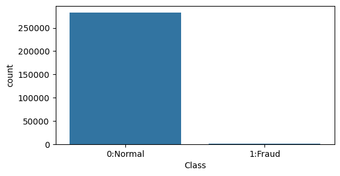

```python
plt.figure(figsize=(6,3))
ax=sns.countplot(data=data, x='Class')
ax.set_xticklabels(['0:Normal', '1:Fraud'])
plt.show()
```

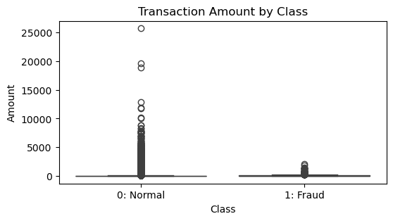

```python
plt.figure(figsize=(6,3))
sns.boxplot(x='Class', y= 'Amount', data= data)
plt.title('Transaction Amount by Class')
plt.xticks(ticks=[0,1], labels=['0: Normal', '1: Fraud'])
plt.show()
```

```python
data['Hours'] = ((data['Time'] // 3600)%24).astype(int)
```

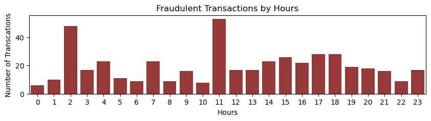

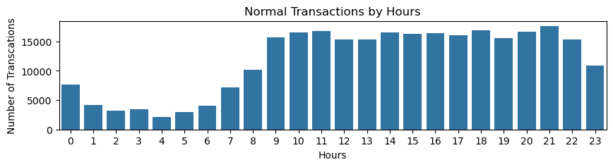

```python
plt.figure(figsize=(10,2))
sns.countplot(data=data[data['Class']==1],x='Hours',color='brown')
plt.title('Fraudulent Transactions by Hours')
plt.ylabel('Number of Transcations')
plt.show()

plt.figure(figsize=(10,2))
sns.countplot(data=data[data['Class']==0],x='Hours')
plt.title('Normal Transactions by Hours')
plt.ylabel('Number of Transcations')
plt.show()
```

## 4. Data Preprocessing

We perform critical preprocessing steps to improve model performance:

1. Apply sine and cosine transformation to the hour of day to capture cyclical patterns.
2. Standardize `Amount` feature.
3. Drop the original `Time`, `Hours` and `Amount`columns.

```python
df = data.copy()
df['Hours_sin'] = np.sin(2*np.pi*df['Hours']/24)
df['Hours_cos'] = np.cos(2*np.pi*df['Hours']/24)

std_scaler= StandardScaler()
df[['Amount_sca']] = std_scaler.fit_transform(df[['Amount']])

df.drop(['Time','Hours','Amount'], axis=1, inplace=True)
```

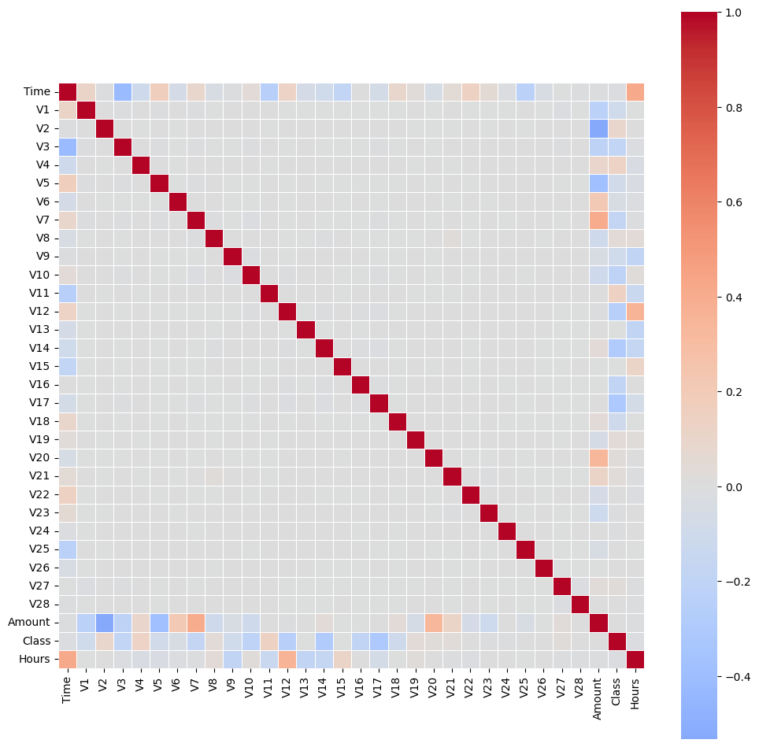

```python
plt.figure(figsize=(12,12))
sns.heatmap(data.corr(),
            cmap='coolwarm',
            center=0,
            linecolor='white',
            linewidths=0.5,
            square=True
           )

plt.show()
```

```python
df.columns
```

```
Index(['V1', 'V2', 'V3', 'V4', 'V5', 'V6', 'V7', 'V8', 'V9', 'V10', 'V11',
       'V12', 'V13', 'V14', 'V15', 'V16', 'V17', 'V18', 'V19', 'V20', 'V21',
       'V22', 'V23', 'V24', 'V25', 'V26', 'V27', 'V28', 'Class', 'Hours_sin',
       'Hours_cos', 'Amount_sca'],
      dtype='object')
```

```python
X = df.drop('Class', axis=1)
y = df['Class']
X_train, X_test, y_train, y_test = train_test_split(
    X, y, test_size=0.2, random_state=10, stratify=y)
```

## 5. Modelling and Evaluation

```python
model = XGBClassifier(
    scale_pos_weight = sum(y_train==0)/sum(y_train==1),
    eval_metric='logloss',
    random_state=5,
)
model.fit(X_train,y_train)

y_pred = model.predict(X_test)
print(classification_report(y_test, y_pred, digits=4))
```

```
              precision    recall  f1-score   support

           0     0.9997    0.9999    0.9998     56651
           1     0.9091    0.8421    0.8743        95

    accuracy                         0.9996     56746
   macro avg     0.9544    0.9210    0.9371     56746
weighted avg     0.9996    0.9996    0.9996     56746
```

```python
scores = cross_val_score(model, X, y, cv=5, scoring='f1')
print("F1 scores:", scores)
print("confusion_matrix:",confusion_matrix(y_test,y_pred))
```

```
F1 scores: [0.75555556 0.8988764  0.58986175 0.85082873 0.81176471]
confusion_matrix: [[56643     8]
 [   15    80]]
```

## 6. Conclusion

We conducted exploratory data analysis on a credit card fraud dataset and built a fraud detection model using XGBoost. The model achieved high performance in terms of precision and reall.

However, there are several areas for improvement in future work:

- We identified some potentially irrelecant features but did not remove them which may introduce noise.
- The model was not compared with other algorithms.
- The model was trained using mostly default hyperparameters, with minimal tuning.

In summary, this project provides a basic framework for fraud detection modeling, which can be improved and expanded upon in future work.

## Reference

**Credit Card Fraud Detection**(2013). Kaggle Dataset. Available at https://www.kaggle.com/datasets/mlg-ulb/creditcardfraud